# Ch 2 Plots

Mikaela Provost

August 27, 2019

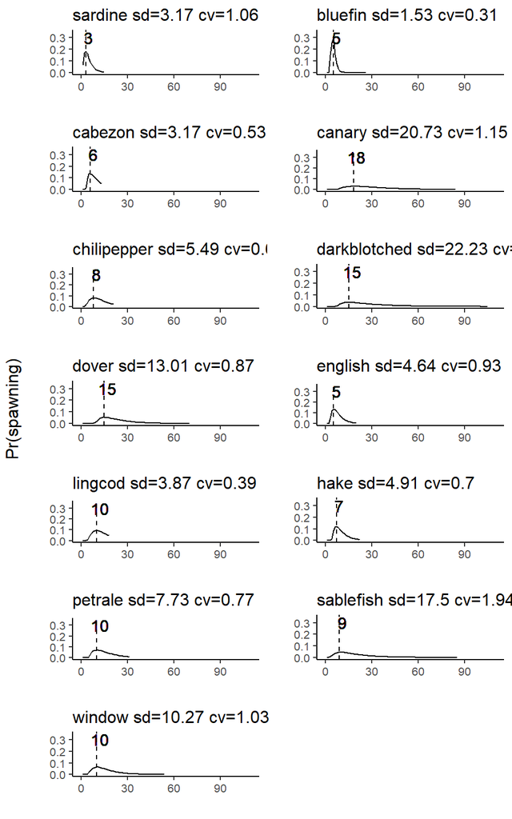

Figure 1. Distribution of spawning biomass across ages Dashed line and number indicate peak spawning age, standard deviation and coefficient of variation are listed at the top of each subplot. Distributions are probability of spawning at age: LEP-at-age/total LEP, where LEP-at-age is a function of egg production at age, probability of being mature, and survival from age 1 to age a.

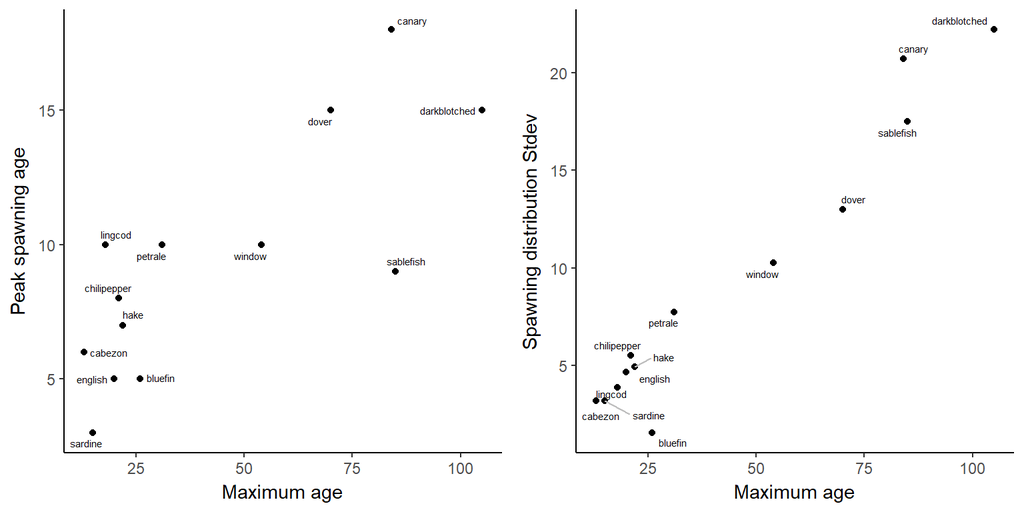

Figure 2. The relationship between (a) peak spawning age and maximum age, and (b) standard deviation of the spawning biomass distribution and maximum age.

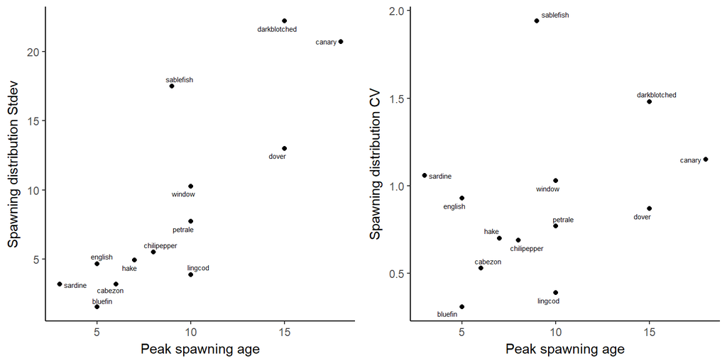

Figure 3. (a) Standard deviation of spawning distribution vs peak spawning age. (b) Spawning distribution CV vs peak spawning age.

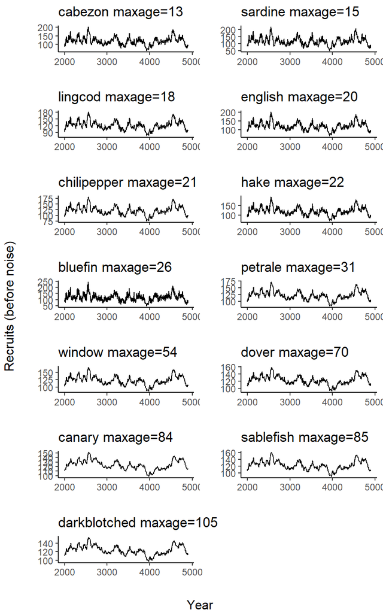

Figure 4. Time series of recruits before noise for PFMC species. No fishing is included in simulations. Lifetime egg production and recruitment variation is made constant for all species (LEP=1.1, sigmaR=0.3).

[figure not shown]

Figure 5. Spectra of recruitment time series. Smoother is 55 years.

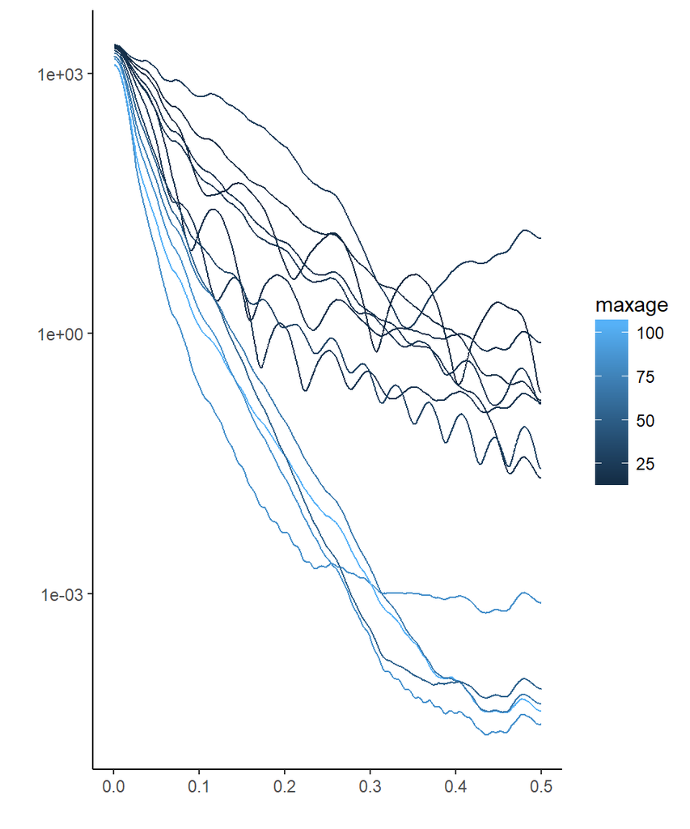

Figure 6. Spectra of recruitment time series. Color indicates species maximum age. Smoother is 55 years.

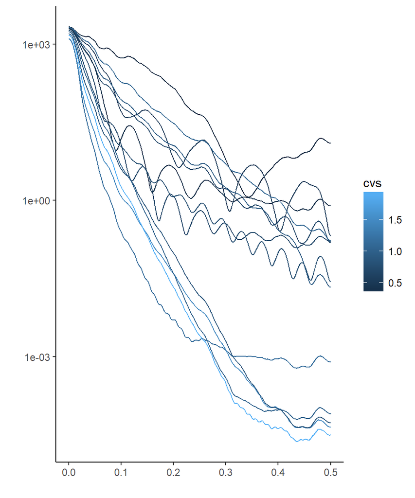

Figure 7. Spectra of recruitment time series. Color indicates spawning distribution CV. Smoother is 55 years.

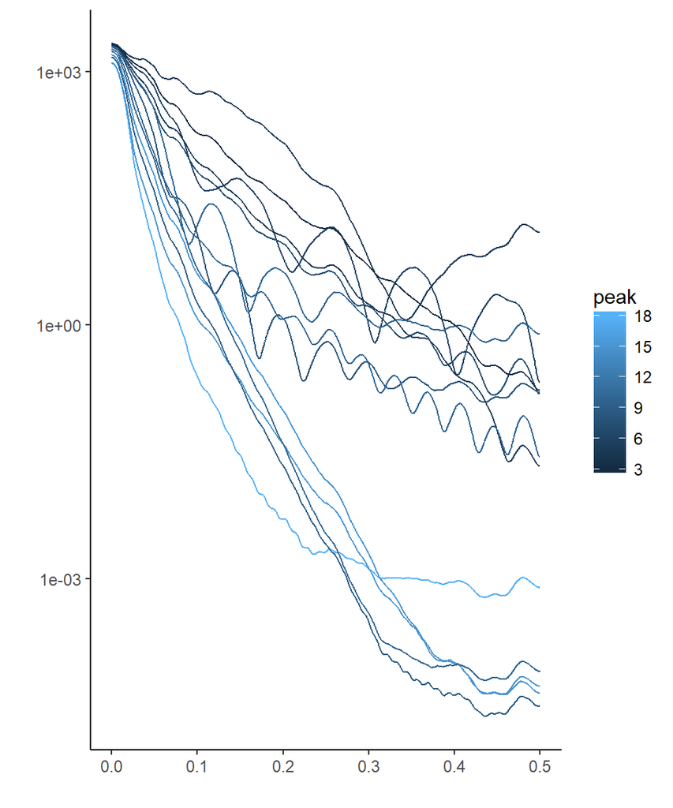

Figure 8. Spectra of recruitment time series. Color indicates species peak spawning age. Smoother is 55 years.

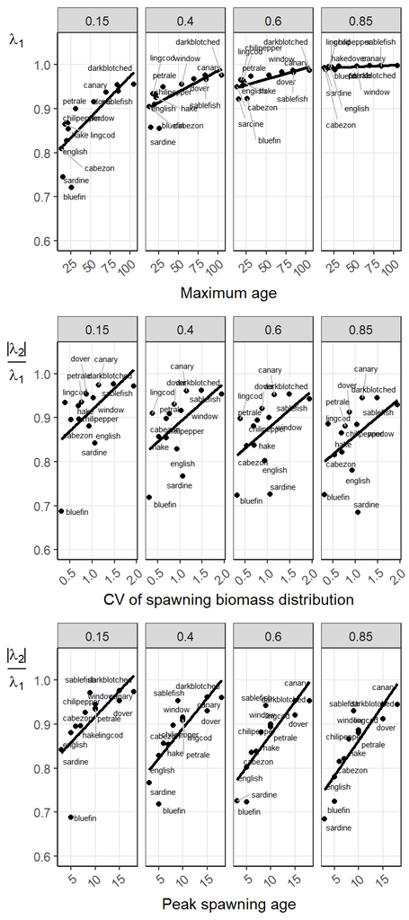

Figure 9. (a) The relationship between Lambda 1 and longevity, (b) the inverse of the damping ratio (1/DR) versus spawning biomass distribution CV, and (c) 1/DR versus peak spawning age.

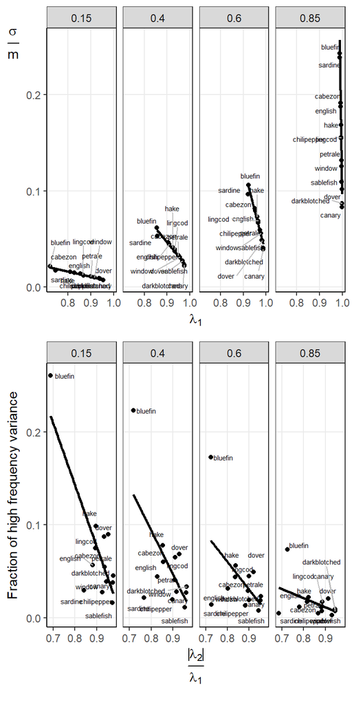

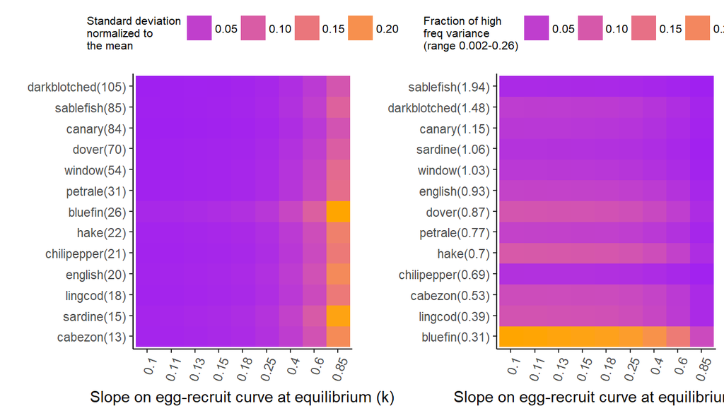

Figure 11. Figure 4. (a) The color of each cell indicates the standard deviation of recruitment relative to mean recruitment for a single population at different values of k (slopes at equilibrium along the egg-recruit curve). Numbers in parentheses next to population names is longevity of that species, populations are ordered by decreasing maximum age. (b) Each cell represents the fraction of total variance in recruitment time series concentrated at high frequencies. High frequency is defined as frequencies between 1/2T and 0.5 for all populations. Numbers in parentheses indicate CV of the spawning biomass distribution, populations are ordered by decreasing CV. In both (a) and (b) dark purple colors represent lower values and bright orange represents higher values.